# hw10

Emily West

11/28/2017

```r
library(httr)
library(jsonlite)
library(xml2)
library(rvest)
library(purrr)
library(repurrrsive)
library(listviewer)
library(stringi)
library(stringr)
library(knitr)
library(tidyverse)
library(glue)
```

After tinkering with other much less friendly datasets, I opted to work with the starwars API. My intention is to isolate character data and merge it with planet data

# 1.1: Get the data from the internet

In the most basic use of the httr() package, GET() can be used to call data from an API

```r
swchar<-GET("https://swapi.co/api/people")
swpla<-GET("https://swapi.co/api/planets")
```

SWAPI is a friendly API to work with and does not require changing the parameters. For an example of how one would call data from an API requiring an authorization key scroll navigate to [part II] of my homwork for an exercise in using purrr function son data aquired from the NYTimes API.

# 1.2: Use a function to efficiently get multiple datasets

If you are making repeated requests using a specific API a function can be used to streamline the aquisition of data:

```r
get_data<-function(info){GET(glue("https://swapi.co/api/{info}/"))}

#function test:
z<-get_data("starships")
str(z)
```

```
## List of 10
##  $ url        : chr "https://swapi.co/api/starships/"
##  $ status_code: int 200
##  $ headers    :List of 12
##   ..$ date             : chr "Wed, 06 Dec 2017 18:20:19 GMT"
##   ..$ content-type     : chr "application/json"
##   ..$ transfer-encoding: chr "chunked"
##   ..$ connection       : chr "keep-alive"
##   ..$ vary             : chr "Accept, Cookie"
##   ..$ allow            : chr "GET, HEAD, OPTIONS"
##   ..$ x-frame-options  : chr "SAMEORIGIN"
##   ..$ etag             : chr "W/\"9d11d1ceef86e0dc36273bd093bf29f7\""
##   ..$ via              : chr "1.1 vegur"
##   ..$ server           : chr "cloudflare-nginx"
##   ..$ cf-ray           : chr "3c91422c28e63af6-YVR"
##   ..$ content-encoding : chr "gzip"
##   ..- attr(*, "class")= chr [1:2] "insensitive" "list"
##  $ all_headers:List of 1
##   ..$ :List of 3
##   .. ..$ status : int 200
##   .. ..$ version: chr "HTTP/1.1"
##   .. ..$ headers:List of 12
##   .. .. ..$ date             : chr "Wed, 06 Dec 2017 18:20:19 GMT"
##   .. .. ..$ content-type     : chr "application/json"
##   .. .. ..$ transfer-encoding: chr "chunked"
##   .. .. ..$ connection       : chr "keep-alive"
##   .. .. ..$ vary             : chr "Accept, Cookie"
##   .. .. ..$ allow            : chr "GET, HEAD, OPTIONS"
##   .. .. ..$ x-frame-options  : chr "SAMEORIGIN"
##   .. .. ..$ etag             : chr "W/\"9d11d1ceef86e0dc36273bd093bf29f7\""
##   .. .. ..$ via              : chr "1.1 vegur"
##   .. .. ..$ server           : chr "cloudflare-nginx"
##   .. .. ..$ cf-ray           : chr "3c91422c28e63af6-YVR"
##   .. .. ..$ content-encoding : chr "gzip"
##   .. .. ..- attr(*, "class")= chr [1:2] "insensitive" "list"
##  $ cookies    :'data.frame': 1 obs. of  7 variables:
##   ..$ domain    : chr "#HttpOnly_.swapi.co"
##   ..$ flag      : logi TRUE
##   ..$ path      : chr "/"
##   ..$ secure    : logi TRUE
##   ..$ expiration: POSIXct[1:1], format: "2018-12-06 18:20:17"
##   ..$ name      : chr "__cfduid"
##   ..$ value     : chr "df5d28253eab0953a6e8963a77b25b52b1512584417"
##  $ content    : raw [1:6025] 7b 22 63 6f ...
##  $ date       : POSIXct[1:1], format: "2017-12-06 18:20:19"
##  $ times      : Named num [1:6] 0 0.000036 0.000038 0.000121 0.164806 ...
##   ..- attr(*, "names")= chr [1:6] "redirect" "namelookup" "connect" "pretransfer" ...
##  $ request    :List of 7
##   ..$ method    : chr "GET"
##   ..$ url       :Classes 'glue', 'character'  chr "https://swapi.co/api/starships/"
##   ..$ headers   : Named chr "application/json, text/xml, application/xml, */*"
##   .. ..- attr(*, "names")= chr "Accept"
##   ..$ fields    : NULL
##   ..$ options   :List of 2
##   .. ..$ useragent: chr "libcurl/7.54.0 r-curl/3.0 httr/1.3.1"
##   .. ..$ httpget  : logi TRUE
##   ..$ auth_token: NULL
##   ..$ output    : list()
##   .. ..- attr(*, "class")= chr [1:2] "write_memory" "write_function"
##   ..- attr(*, "class")= chr "request"
##  $ handle     :Class 'curl_handle' <externalptr>
##  - attr(*, "class")= chr "response"
```

```r
str(swpla)
```

```
## List of 10
##  $ url        : chr "https://swapi.co/api/planets/"
##  $ status_code: int 200
##  $ headers    :List of 12
##   ..$ date             : chr "Wed, 06 Dec 2017 18:20:19 GMT"
##   ..$ content-type     : chr "application/json"
##   ..$ transfer-encoding: chr "chunked"
##   ..$ connection       : chr "keep-alive"
##   ..$ vary             : chr "Accept, Cookie"
##   ..$ allow            : chr "GET, HEAD, OPTIONS"
##   ..$ x-frame-options  : chr "SAMEORIGIN"
##   ..$ etag             : chr "W/\"394d177de8df8accc41f9427b749ef4a\""
##   ..$ via              : chr "1.1 vegur"
##   ..$ server           : chr "cloudflare-nginx"
##   ..$ cf-ray           : chr "3c91422a68823af6-YVR"
##   ..$ content-encoding : chr "gzip"
##   ..- attr(*, "class")= chr [1:2] "insensitive" "list"
##  $ all_headers:List of 2
##   ..$ :List of 3
##   .. ..$ status : int 301
##   .. ..$ version: chr "HTTP/1.1"
##   .. ..$ headers:List of 9
##   .. .. ..$ date             : chr "Wed, 06 Dec 2017 18:20:18 GMT"
##   .. .. ..$ content-type     : chr "text/html; charset=utf-8"
##   .. .. ..$ transfer-encoding: chr "chunked"
##   .. .. ..$ connection       : chr "keep-alive"
##   .. .. ..$ location         : chr "https://swapi.co/api/planets/"
##   .. .. ..$ x-frame-options  : chr "SAMEORIGIN"
##   .. .. ..$ via              : chr "1.1 vegur"
##   .. .. ..$ server           : chr "cloudflare-nginx"
##   .. .. ..$ cf-ray           : chr "3c9142281fde3af6-YVR"
##   .. .. ..- attr(*, "class")= chr [1:2] "insensitive" "list"
##   ..$ :List of 3
##   .. ..$ status : int 200
##   .. ..$ version: chr "HTTP/1.1"
##   .. ..$ headers:List of 12
##   .. .. ..$ date             : chr "Wed, 06 Dec 2017 18:20:19 GMT"
##   .. .. ..$ content-type     : chr "application/json"
##   .. .. ..$ transfer-encoding: chr "chunked"
##   .. .. ..$ connection       : chr "keep-alive"
```

[output cut: 21 more lines]

```
##  $ request    :List of 7
##   ..$ method    : chr "GET"
##   ..$ url       : chr "https://swapi.co/api/planets"
##   ..$ headers   : Named chr "application/json, text/xml, application/xml, */*"
##   .. ..- attr(*, "names")= chr "Accept"
##   ..$ fields    : NULL
##   ..$ options   :List of 2
##   .. ..$ useragent: chr "libcurl/7.54.0 r-curl/3.0 httr/1.3.1"
##   .. ..$ httpget  : logi TRUE
##   ..$ auth_token: NULL
##   ..$ output    : list()
##   .. ..- attr(*, "class")= chr [1:2] "write_memory" "write_function"
##   ..- attr(*, "class")= chr "request"
##  $ handle     :Class 'curl_handle' <externalptr>
##  - attr(*, "class")= chr "response"
```

# 1.3: Work with starwars character data first:

```r
str(swchar)
```

```
## List of 10
##  $ url        : chr "https://swapi.co/api/people/"
##  $ status_code: int 200
##  $ headers    :List of 12
##   ..$ date             : chr "Wed, 06 Dec 2017 18:20:18 GMT"
##   ..$ content-type     : chr "application/json"
##   ..$ transfer-encoding: chr "chunked"
##   ..$ connection       : chr "keep-alive"
##   ..$ vary             : chr "Accept, Cookie"
##   ..$ allow            : chr "GET, HEAD, OPTIONS"
##   ..$ x-frame-options  : chr "SAMEORIGIN"
##   ..$ etag             : chr "W/\"d080408a4d656729b0f52a6feb0783ca\""
##   ..$ via              : chr "1.1 vegur"
##   ..$ server           : chr "cloudflare-nginx"
##   ..$ cf-ray           : chr "3c914223dee33af6-YVR"
##   ..$ content-encoding : chr "gzip"
##   ..- attr(*, "class")= chr [1:2] "insensitive" "list"
##  $ all_headers:List of 2
##   ..$ :List of 3
##   .. ..$ status : int 301
##   .. ..$ version: chr "HTTP/1.1"
##   .. ..$ headers:List of 10
##   .. .. ..$ date             : chr "Wed, 06 Dec 2017 18:20:17 GMT"
##   .. .. ..$ content-type     : chr "text/html; charset=utf-8"
##   .. .. ..$ transfer-encoding: chr "chunked"
##   .. .. ..$ connection       : chr "keep-alive"
##   .. .. ..$ set-cookie       : chr "__cfduid=df5d28253eab0953a6e8963a77b25b52b1512584417; expires=Thu, 06-Dec-18 18:20:17 GMT; path=/; domain=.swap"| __truncated__
##   .. .. ..$ location         : chr "https://swapi.co/api/people/"
##   .. .. ..$ x-frame-options  : chr "SAMEORIGIN"
##   .. .. ..$ via              : chr "1.1 vegur"
##   .. .. ..$ server           : chr "cloudflare-nginx"
##   .. .. ..$ cf-ray           : chr "3c914221ae793af6-YVR"
##   .. .. ..- attr(*, "class")= chr [1:2] "insensitive" "list"
##   ..$ :List of 3
##   .. ..$ status : int 200
##   .. ..$ version: chr "HTTP/1.1"
##   .. ..$ headers:List of 12
##   .. .. ..$ date             : chr "Wed, 06 Dec 2017 18:20:18 GMT"
##   .. .. ..$ content-type     : chr "application/json"
##   .. .. ..$ transfer-encoding: chr "chunked"
```

[output cut: 22 more lines]

```
##  $ request    :List of 7
##   ..$ method    : chr "GET"
##   ..$ url       : chr "https://swapi.co/api/people"
##   ..$ headers   : Named chr "application/json, text/xml, application/xml, */*"
##   .. ..- attr(*, "names")= chr "Accept"
##   ..$ fields    : NULL
##   ..$ options   :List of 2
##   .. ..$ useragent: chr "libcurl/7.54.0 r-curl/3.0 httr/1.3.1"
##   .. ..$ httpget  : logi TRUE
##   ..$ auth_token: NULL
##   ..$ output    : list()
##   .. ..- attr(*, "class")= chr [1:2] "write_memory" "write_function"
##   ..- attr(*, "class")= chr "request"
##  $ handle     :Class 'curl_handle' <externalptr>
##  - attr(*, "class")= chr "response"
```

That’s a big ole mess of information, but importantly, it tells me where the data are coming from as well as the status code. A status code value of 200, which we have here, means a successful call!

```r
scres<-content(swchar)
scres$results[[2]]$name #subset data using position
```

```
## [1] "C-3PO"
```

```r
#stringi::stri_enc_detect(content(swchar, "raw"))
json<-content(swchar, as = "text", encoding = "ISO-8859-1")
thing<- fromJSON(json) #from JSON puts object into a JSON readable format
head(thing)
```

```
## $count
## [1] 87
##
## $`next`
## [1] "https://swapi.co/api/people/?page=2"
##
## $previous
## NULL
##
## $results
##                  name height mass    hair_color  skin_color eye_color
## 1      Luke Skywalker    172   77         blond        fair      blue
## 2               C-3PO    167   75           n/a        gold    yellow
## 3               R2-D2     96   32           n/a white, blue       red
## 4         Darth Vader    202  136          none       white    yellow
```

[output cut: 83 more lines]

View(thing) #check out in a “readable” fashion what the swchar looks like

jsonedit(thing) #(this function is not Rmd friendly?)

```
            #but it shows why inspecting your data is so important!

            #All the interesting information is nested within results

            #The data are presented in long format
```

In order to isolate the interesting stuff and create a dataframe from it, I went down a twisted path, here is a taste of how it started:

```r
map(thing, "height")
```

```
## $count
## NULL
##
## $`next`
## NULL
##
## $previous
## NULL
##
## $results
##  [1] "172" "167" "96"  "202" "150" "178" "165" "97"  "183" "182"
```

```r
(ht<-map(thing, "height")) #Within the list I want to isolate the elements associated with each character, i.e. height, gender, eye color etc.
```

```
## $count
## NULL
##
## $`next`
## NULL
##
## $previous
## NULL
##
## $results
##  [1] "172" "167" "96"  "202" "150" "178" "165" "97"  "183" "182"
```

```r
#unfortunately this mapping function pulls all the elements preceeding $results
ht<-(ht[4]) #this selection calls only the $results, as a singular vector
(ht)
```

```
## $results
##  [1] "172" "167" "96"  "202" "150" "178" "165" "97"  "183" "182"
```

```r
is.vector(ht) #just checking that this is indeed a vector
```

```
## [1] TRUE
```

because I had the uninspired idea to do this for all character attributes, creating a dataset by hand, I decided to build a function:

```r
esel<-function(data, attribute, selector){
  x<-map(data, attribute)
  x[selector]
}

char<-esel(thing, "name", 4) #map character names
ht2<-esel(thing, "height", 4) #map character height
names(ht2)
```

```
## [1] "results"
```

```r
str(char) #what do these data look like?
```

```
## List of 1
##  $ results: chr [1:10] "Luke Skywalker" "C-3PO" "R2-D2" "Darth Vader" ...
```

But then I discovered purrr had already solved my troubles with the reduce() function:

```r
is.data.frame(thing) #nope, not a dataframe
```

```
## [1] FALSE
```

```r
is.list(thing) #yep, it is a list
```

```
## [1] TRUE
```

```r
chardf<-reduce(thing,cbind)
is.data.frame(chardf)
```

```
## [1] TRUE
```

```r
str(chardf)
```

```
## 'data.frame':    10 obs. of  18 variables:
##  $ out       : Factor w/ 1 level "87": 1 1 1 1 1 1 1 1 1 1
##   ..- attr(*, "names")= chr  "out" "out" "out" "out" ...
##  $ V2        : Factor w/ 1 level "https://swapi.co/api/people/?page=2": 1 1 1 1 1 1 1 1 1 1
##   ..- attr(*, "names")= chr  "" "" "" "" ...
##  $ name      : chr  "Luke Skywalker" "C-3PO" "R2-D2" "Darth Vader" ...
##  $ height    : chr  "172" "167" "96" "202" ...
##  $ mass      : chr  "77" "75" "32" "136" ...
##  $ hair_color: chr  "blond" "n/a" "n/a" "none" ...
##  $ skin_color: chr  "fair" "gold" "white, blue" "white" ...
##  $ eye_color : chr  "blue" "yellow" "red" "yellow" ...
##  $ birth_year: chr  "19BBY" "112BBY" "33BBY" "41.9BBY" ...
##  $ gender    : chr  "male" "n/a" "n/a" "male" ...
##  $ homeworld : chr  "https://swapi.co/api/planets/1/" "https://swapi.co/api/planets/1/" "https://swapi.co/api/planets/8/" "https://swapi.co/api/planets/1/" ...
##  $ films     :List of 10
##   ..$ : chr  "https://swapi.co/api/films/2/" "https://swapi.co/api/films/6/" "https://swapi.co/api/films/3/" "https://swapi.co/api/films/1/" ...
##   ..$ : chr  "https://swapi.co/api/films/2/" "https://swapi.co/api/films/5/" "https://swapi.co/api/films/4/" "https://swapi.co/api/films/6/" ...
##   ..$ : chr  "https://swapi.co/api/films/2/" "https://swapi.co/api/films/5/" "https://swapi.co/api/films/4/" "https://swapi.co/api/films/6/" ...
##   ..$ : chr  "https://swapi.co/api/films/2/" "https://swapi.co/api/films/6/" "https://swapi.co/api/films/3/" "https://swapi.co/api/films/1/"
##   ..$ : chr  "https://swapi.co/api/films/2/" "https://swapi.co/api/films/6/" "https://swapi.co/api/films/3/" "https://swapi.co/api/films/1/" ...
##   ..$ : chr  "https://swapi.co/api/films/5/" "https://swapi.co/api/films/6/" "https://swapi.co/api/films/1/"
##   ..$ : chr  "https://swapi.co/api/films/5/" "https://swapi.co/api/films/6/" "https://swapi.co/api/films/1/"
##   ..$ : chr "https://swapi.co/api/films/1/"
##   ..$ : chr "https://swapi.co/api/films/1/"
##   ..$ : chr  "https://swapi.co/api/films/2/" "https://swapi.co/api/films/5/" "https://swapi.co/api/films/4/" "https://swapi.co/api/films/6/" ...
##  $ species   :List of 10
##   ..$ : chr "https://swapi.co/api/species/1/"
##   ..$ : chr "https://swapi.co/api/species/2/"
##   ..$ : chr "https://swapi.co/api/species/2/"
##   ..$ : chr "https://swapi.co/api/species/1/"
##   ..$ : chr "https://swapi.co/api/species/1/"
##   ..$ : chr "https://swapi.co/api/species/1/"
##   ..$ : chr "https://swapi.co/api/species/1/"
##   ..$ : chr "https://swapi.co/api/species/2/"
##   ..$ : chr "https://swapi.co/api/species/1/"
##   ..$ : chr "https://swapi.co/api/species/1/"
##  $ vehicles  :List of 10
##   ..$ : chr  "https://swapi.co/api/vehicles/14/" "https://swapi.co/api/vehicles/30/"
##   ..$ : chr
##   ..$ : chr
##   ..$ : chr
##   ..$ : chr "https://swapi.co/api/vehicles/30/"
##   ..$ : chr
##   ..$ : chr
##   ..$ : chr
##   ..$ : chr
##   ..$ : chr "https://swapi.co/api/vehicles/38/"
##  $ starships :List of 10
##   ..$ : chr  "https://swapi.co/api/starships/12/" "https://swapi.co/api/starships/22/"
##   ..$ : chr
##   ..$ : chr
##   ..$ : chr "https://swapi.co/api/starships/13/"
##   ..$ : chr
##   ..$ : chr
##   ..$ : chr
##   ..$ : chr
##   ..$ : chr "https://swapi.co/api/starships/12/"
##   ..$ : chr  "https://swapi.co/api/starships/48/" "https://swapi.co/api/starships/59/" "https://swapi.co/api/starships/64/" "https://swapi.co/api/starships/65/" ...
##  $ created   : chr  "2014-12-09T13:50:51.644000Z" "2014-12-10T15:10:51.357000Z" "2014-12-10T15:11:50.376000Z" "2014-12-10T15:18:20.704000Z" ...
##  $ edited    : chr  "2014-12-20T21:17:56.891000Z" "2014-12-20T21:17:50.309000Z" "2014-12-20T21:17:50.311000Z" "2014-12-20T21:17:50.313000Z" ...
##  $ url       : chr  "https://swapi.co/api/people/1/" "https://swapi.co/api/people/2/" "https://swapi.co/api/people/3/" "https://swapi.co/api/people/4/" ...
```

```r
#View(chardf)
kable(chardf)
```

| out | V2 | name | height | mass | hair_color | skin_color | eye_color | birth_year | gender | homeworld | films | species | vehicles | starships | created | edited | url |
| --- | --- | --- | --- | --- | --- | --- | --- | --- | --- | --- | --- | --- | --- | --- | --- | --- | --- |
| 87 | https://swapi.co/api/people/?page=2 | Luke Skywalker | 172 | 77 | blond | fair | blue | 19BBY | male | https://swapi.co/api/planets/1/ | https://swapi.co/api/films/2/, https://swapi.co/api/films/6/, https://swapi.co/api/films/3/, https://swapi.co/api/films/1/, https://swapi.co/api/films/7/ | https://swapi.co/api/species/1/ | https://swapi.co/api/vehicles/14/, https://swapi.co/api/vehicles/30/ | https://swapi.co/api/starships/12/, https://swapi.co/api/starships/22/ | 2014-12-09T13:50:51.644000Z | 2014-12-20T21:17:56.891000Z | https://swapi.co/api/people/1/ |
| 87 | https://swapi.co/api/people/?page=2 | C-3PO | 167 | 75 | n/a | gold | yellow | 112BBY | n/a | https://swapi.co/api/planets/1/ | https://swapi.co/api/films/2/, https://swapi.co/api/films/5/, https://swapi.co/api/films/4/, https://swapi.co/api/films/6/, https://swapi.co/api/films/3/, https://swapi.co/api/films/1/ | https://swapi.co/api/species/2/ |  |  | 2014-12-10T15:10:51.357000Z | 2014-12-20T21:17:50.309000Z | https://swapi.co/api/people/2/ |
| 87 | https://swapi.co/api/people/?page=2 | R2-D2 | 96 | 32 | n/a | white, blue | red | 33BBY | n/a | https://swapi.co/api/planets/8/ | https://swapi.co/api/films/2/, https://swapi.co/api/films/5/, https://swapi.co/api/films/4/, https://swapi.co/api/films/6/, https://swapi.co/api/films/3/, https://swapi.co/api/films/1/, https://swapi.… | https://swapi.co/api/species/2/ |  |  | 2014-12-10T15:11:50.376000Z | 2014-12-20T21:17:50.311000Z | https://swapi.co/api/people/3/ |
| 87 | https://swapi.co/api/people/?page=2 | Darth Vader | 202 | 136 | none | white | yellow | 41.9BBY | male | https://swapi.co/api/planets/1/ | https://swapi.co/api/films/2/, https://swapi.co/api/films/6/, https://swapi.co/api/films/3/, https://swapi.co/api/films/1/ | https://swapi.co/api/species/1/ |  | https://swapi.co/api/starships/13/ | 2014-12-10T15:18:20.704000Z | 2014-12-20T21:17:50.313000Z | https://swapi.co/api/people/4/ |
| 87 | https://swapi.co/api/people/?page=2 | Leia Organa | 150 | 49 | brown | light | brown | 19BBY | female | https://swapi.co/api/planets/2/ | https://swapi.co/api/films/2/, https://swapi.co/api/films/6/, https://swapi.co/api/films/3/, https://swapi.co/api/films/1/, https://swapi.co/api/films/7/ | https://swapi.co/api/species/1/ | https://swapi.co/api/vehicles/30/ |  | 2014-12-10T15:20:09.791000Z | 2014-12-20T21:17:50.315000Z | https://swapi.co/api/people/5/ |
| 87 | https://swapi.co/api/people/?page=2 | Owen Lars | 178 | 120 | brown, grey | light | blue | 52BBY | male | https://swapi.co/api/planets/1/ | https://swapi.co/api/films/5/, https://swapi.co/api/films/6/, https://swapi.co/api/films/1/ | https://swapi.co/api/species/1/ |  |  | 2014-12-10T15:52:14.024000Z | 2014-12-20T21:17:50.317000Z | https://swapi.co/api/people/6/ |
| 87 | https://swapi.co/api/people/?page=2 | Beru Whitesun lars | 165 | 75 | brown | light | blue | 47BBY | female | https://swapi.co/api/planets/1/ | https://swapi.co/api/films/5/, https://swapi.co/api/films/6/, https://swapi.co/api/films/1/ | https://swapi.co/api/species/1/ |  |  | 2014-12-10T15:53:41.121000Z | 2014-12-20T21:17:50.319000Z | https://swapi.co/api/people/7/ |
| 87 | https://swapi.co/api/people/?page=2 | R5-D4 | 97 | 32 | n/a | white, red | red | unknown | n/a | https://swapi.co/api/planets/1/ | https://swapi.co/api/films/1/ | https://swapi.co/api/species/2/ |  |  | 2014-12-10T15:57:50.959000Z | 2014-12-20T21:17:50.321000Z | https://swapi.co/api/people/8/ |
| 87 | https://swapi.co/api/people/?page=2 | Biggs Darklighter | 183 | 84 | black | light | brown | 24BBY | male | https://swapi.co/api/planets/1/ | https://swapi.co/api/films/1/ | https://swapi.co/api/species/1/ |  | https://swapi.co/api/starships/12/ | 2014-12-10T15:59:50.509000Z | 2014-12-20T21:17:50.323000Z | https://swapi.co/api/people/9/ |
| 87 | https://swapi.co/api/people/?page=2 | Obi-Wan Kenobi | 182 | 77 | auburn, white | fair | blue-gray | 57BBY | male | https://swapi.co/api/planets/20/ | https://swapi.co/api/films/2/, https://swapi.co/api/films/5/, https://swapi.co/api/films/4/, https://swapi.co/api/films/6/, https://swapi.co/api/films/3/, https://swapi.co/api/films/1/ | https://swapi.co/api/species/1/ | https://swapi.co/api/vehicles/38/ | https://swapi.co/api/starships/48/, https://swapi.co/api/starships/59/, https://swapi.co/api/starships/64/, https://swapi.co/api/starships/65/, https://swapi.co/api/starships/74/ | 2014-12-10T16:16:29.192000Z | 2014-12-20T21:17:50.325000Z | https://swapi.co/api/people/10/ |

Note: the reduce() function ONLY works because of the shape of the data, where by each list attribute is composed of 10 corresponding elements. That is, all Luke Skywalker’s information belongs in the first location of each list element, so when the cbind is used it properly lines up character attributes. This is a dangerous assumption to make when using messier datasets.

# 1.4 Plotting Character data

```r
str(chardf$height) #yikes, height and mass data are both being treated as character strings
```

```
##  chr [1:10] "172" "167" "96" "202" "150" "178" "165" "97" "183" "182"
```

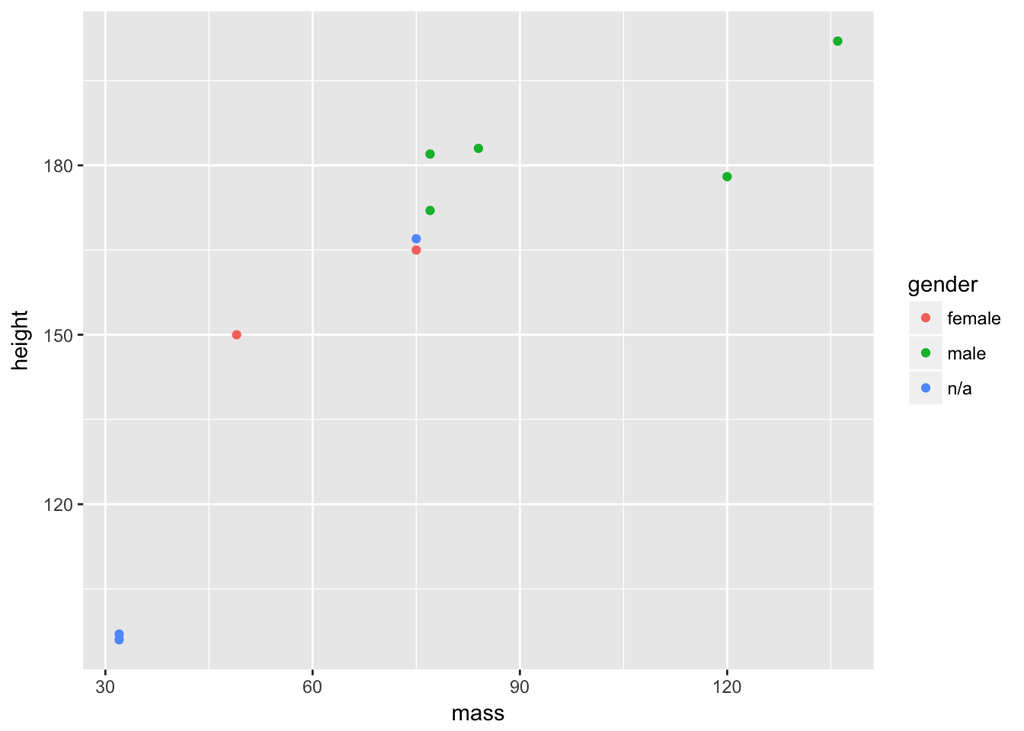

```r
chardf$height<-as.integer(chardf$height)
chardf$mass<-as.integer(chardf$mass)
ggplot(chardf, aes(mass, height, colour = gender)) + geom_point()
```

Yea, we have the character data! But there is still some information that would be nice to know, like where these characters are from. Instead of doing this by hand I created a function that utilizes the web address from the “homeworld” column and calls the information from the API to populate a new column “homeplanet”

1.6 Getting homeplanet data by using the dataset I’ve already downloaded to define the internet source:

First, get rid of unnecessary columns:

```r
charinfo<- chardf %>% select(name, height, mass, hair_color, eye_color,
                             skin_color, birth_year,gender, homeworld)

#Now, try to get the homeplanet by referencing dataframe location:
url_planet<-chardf$homeworld[1]
planets<-GET(url_planet)
 x<-content(planets, as = "text", encoding = "ISO-8859-1")
  y<-fromJSON(x)
  #View(y)
  #jsonedit(y)
 y$name
```

```
## [1] "Tatooine"
```

This would work fine if there were only a few characters, but what if there are many, or the dataset is rearranged? Better to query by something more fixed, like character name:

```r
#This function did not come intuitively and I spent sometime drawing out what I wanted as inputs and outputs:
get_planet<-function(character){
  t<-filter(chardf, name==character)
  url_pl<-t$homeworld
  plant<-GET(url_pl)
  f<-content(plant, as = "text", encoding = "ISO-8859-1")
  q<-fromJSON(f)
  #jsonedit(q)
  print(q$name)}

get_planet("R2-D2")
```

```
## [1] "Naboo"
```

```r
get_planet("Darth Vader")
```

```
## [1] "Tatooine"
```

```r
map_chr(charinfo$name,get_planet) #does mapping work? it sure does!
```

```
## [1] "Tatooine"
## [1] "Tatooine"
## [1] "Naboo"
## [1] "Tatooine"
## [1] "Alderaan"
## [1] "Tatooine"
## [1] "Tatooine"
## [1] "Tatooine"
## [1] "Tatooine"
## [1] "Stewjon"
```

```
##  [1] "Tatooine" "Tatooine" "Naboo"    "Tatooine" "Alderaan" "Tatooine"
##  [7] "Tatooine" "Tatooine" "Tatooine" "Stewjon"
```

```r
swapi_charinfo<-mutate(charinfo, homeplanet=map_chr(charinfo$name,get_planet))
```

```
## [1] "Tatooine"
## [1] "Tatooine"
## [1] "Naboo"
## [1] "Tatooine"
## [1] "Alderaan"
## [1] "Tatooine"
## [1] "Tatooine"
## [1] "Tatooine"
## [1] "Tatooine"
## [1] "Stewjon"
```

```r
swapi_charinfo$homeworld<-NULL #drop the unnecessary column for visualization
kable(swapi_charinfo)
```

| name | height | mass | hair_color | eye_color | skin_color | birth_year | gender | homeplanet |
| --- | --- | --- | --- | --- | --- | --- | --- | --- |
| Luke Skywalker | 172 | 77 | blond | blue | fair | 19BBY | male | Tatooine |
| C-3PO | 167 | 75 | n/a | yellow | gold | 112BBY | n/a | Tatooine |
| R2-D2 | 96 | 32 | n/a | red | white, blue | 33BBY | n/a | Naboo |
| Darth Vader | 202 | 136 | none | yellow | white | 41.9BBY | male | Tatooine |
| Leia Organa | 150 | 49 | brown | brown | light | 19BBY | female | Alderaan |
| Owen Lars | 178 | 120 | brown, grey | blue | light | 52BBY | male | Tatooine |
| Beru Whitesun lars | 165 | 75 | brown | blue | light | 47BBY | female | Tatooine |
| R5-D4 | 97 | 32 | n/a | red | white, red | unknown | n/a | Tatooine |
| Biggs Darklighter | 183 | 84 | black | brown | light | 24BBY | male | Tatooine |
| Obi-Wan Kenobi | 182 | 77 | auburn, white | blue-gray | fair | 57BBY | male | Stewjon |

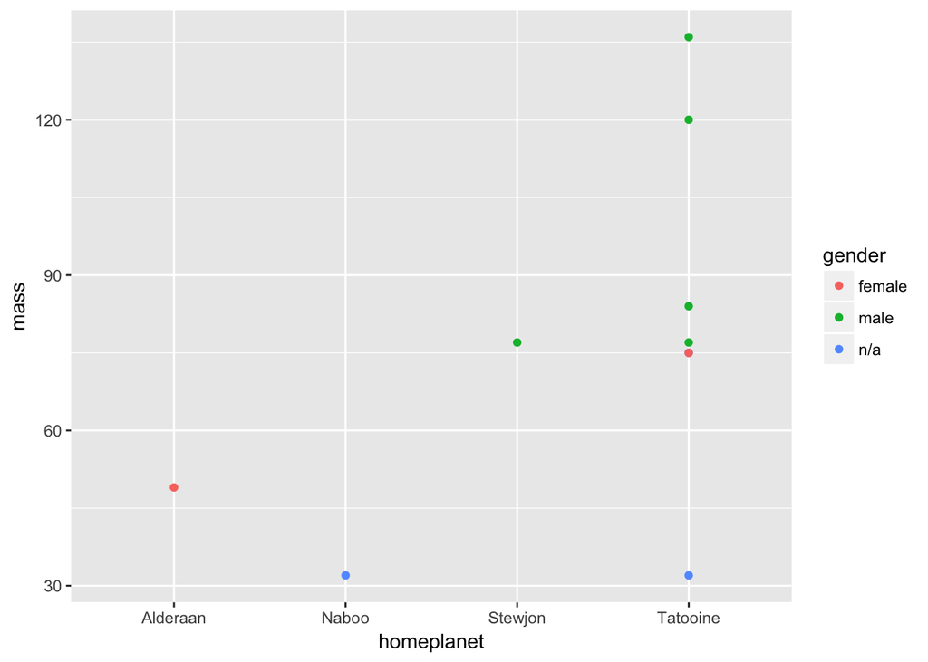

```r
ggplot(swapi_charinfo, aes(homeplanet, mass, colour = gender)) + geom_point()
```